# Refinando o estilo do matplotlib

#### Wilson Freitas

12/06/2014

Categoria: [data science](http://wilsonfreitas.github.io/category/data-science.html)

Tags: [python](http://wilsonfreitas.github.io/tag/python.html) [visualization](http://wilsonfreitas.github.io/tag/visualization.html) [seaborn](http://wilsonfreitas.github.io/tag/seaborn.html) [matplotlib](http://wilsonfreitas.github.io/tag/matplotlib.html)

Na minha opinião, a apresentação do **matplotlib** é miserável. Veja bem, uso bastante o **matplotlib**, mais do que eu gostaria. A minha vida é miserável. Na tentativa de gerar uns gráficos descentes eu esbarrei com o **seaborn**. [seaborn](http://www.stanford.edu/~mwaskom/software/seaborn/) é uma biblioteca de visualização baseada no [matplotlib](http://matplotlib.org/) que possui uma interface de mais alto nível que permite a criação de gráficos estatísticos mais bonitos. O **matplotlib** é altamente configurável, no entanto é difícil conseguir uma configuração que torne os gráficos atraentes, a menos que você tenha uma pós-graduação em artes plásticas. O **seaborn** já vem com alguns temas pré-definidos onde é possível configurar os eixos, a área de fundo, a paleta de cores e o tamanho do gráfico.

No gráfico abaixo temos um gráfico de pontos no **matplotlib** de cara limpa.

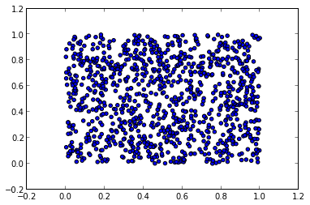

```python
scatter(random.random(1000), random.random(1000));
```

O mesmo gráfico utilizando o modelo padrão do **seaborn** fica:

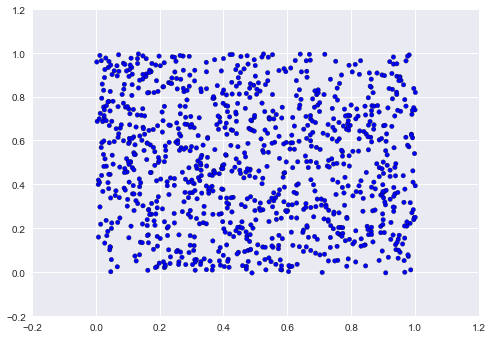

```python
import seaborn as sn
scatter(random.random(1000), random.random(1000));
```

Note que apenas importamos o **seaborn**. Isso já é suficiente para *ativar* o tema padrão do **seaborn**, que na minha opinião é bem mais atraente. O tema padrão é o *darkgrid* que é semelhante ao [ggplot2](http://docs.ggplot2.org/current/) do R. Ainda há mais 4 temas que vamos ver nos gráficos abaixo.

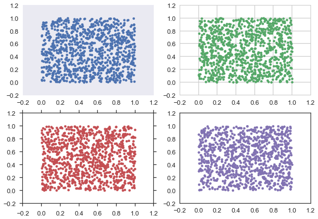

```python
sn.set_context("talk")
with sn.axes_style("dark"):
    subplot(221)
    scatter(random.random(1000), random.random(1000), color=sn.color_palette()[0])
with sn.axes_style("whitegrid"):
    subplot(222)
    scatter(random.random(1000), random.random(1000), color=sn.color_palette()[1])
with sn.axes_style("ticks"):
    subplot(223)
    scatter(random.random(1000), random.random(1000), color=sn.color_palette()[2])
with sn.axes_style("white"):
    subplot(224)
    scatter(random.random(1000), random.random(1000), color=sn.color_palette()[3])
```

Existem outras bibliotecas que trabalham na definição de layout dos gráficos no **matplotlib**:

- mpltools
- [prettyplotlib](http://olgabot.github.io/prettyplotlib/)
- brewer2mpl

Algumas menos intrusivas como é o **seaborn** e outras mais como é o caso do **prettyplotlib**, que mesmo sendo sobre o **matplotlib** faz necessário o uso das suas funções para a criação de gráficos ao invés das funções do **matplotlib**.

Pudemos observar aqui que o **seaborn** permite a criação de gráficos de alto nível com um pequeno custo de configuração.

## Comments

© Wilson Freitas 2015

Powered by Pelican